# Customer Analytics Practice Project

```r
# accuracy of train and test are 0.7 and 0.68 respectively
```

Show variable importance

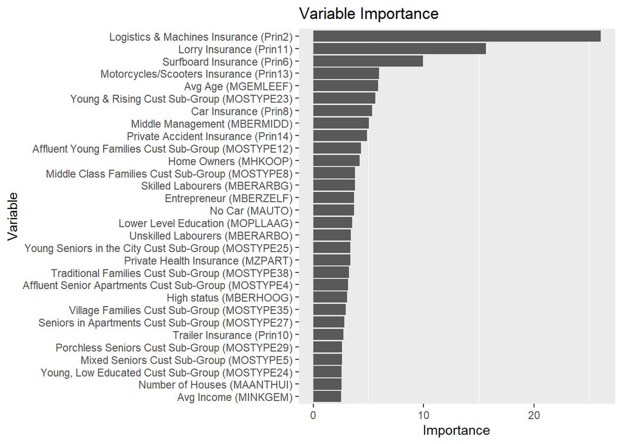

```r
imp = as.data.frame(varImp(model))
imp = data.frame(names   = rownames(imp), overall = imp$Overall)
imp1 = imp[order(imp$overall,decreasing = T),]

# create new variable variable
imp2  = imp1%>%
  mutate(variable = recode_factor(names, "Prin2" = "Logistics & Machines Insurance (Prin2)", "Prin11" = "Lorry Insurance (Prin11)", "Prin6" = "Surfboard Insurance (Prin6)",
                                  "Prin13" = "Motorcycles/Scooters Insurance (Prin13)", "`MGEMLEEF-0`" = "Avg Age (MGEMLEEF)", "MOSTYPE23" = "Young & Rising Cust Sub-Group (MOSTYPE23)",
                                  "Prin8" = "Car Insurance (Prin8)", "`MBERMIDD-0`" = "Middle Management (MBERMIDD)", "Prin14" = "Private Accident Insurance (Prin14)",
                                  "MOSTYPE12" = "Affluent Young Families Cust Sub-Group (MOSTYPE12)", "`MHKOOP-0`" = "Home Owners (MHKOOP)", "MOSTYPE8" = "Middle Class Families Cust Sub-Group (MOSTYPE8)",
                                  "`MBERARBG-0`" = "Skilled Labourers (MBERARBG)", "`MBERZELF-0`" = "Entrepreneur (MBERZELF)", "`MAUT0-0`" = "No Car (MAUTO)", "`MOPLLAAG-0`" = "Lower Level Education (MOPLLAAG)",
                                  "`MBERARBO-0`" = "Unskilled Labourers (MBERARBO)", "MOSTYPE25" = "Young Seniors in the City Cust Sub-Group (MOSTYPE25)", "`MZPART-0`" = "Private Health Insurance (MZPART)",
                                  "MOSTYPE38" = "Traditional Families Cust Sub-Group (MOSTYPE38)", "MOSTYPE4" = "Affluent Senior Apartments Cust Sub-Group (MOSTYPE4)", "`MBERHOOG-0`" = "High status (MBERHOOG)",
                                  "MOSTYPE35" = "Village Families Cust Sub-Group (MOSTYPE35)", "MOSTYPE27" = "Seniors in Apartments Cust Sub-Group (MOSTYPE27)", "Prin10" = "Trailer Insurance (Prin10)",
                                  "MOSTYPE29" = "Porchless Seniors Cust Sub-Group (MOSTYPE29)", "MOSTYPE5" = "Mixed Seniors Cust Sub-Group (MOSTYPE5)", "MOSTYPE24" = "Young, Low Educated Cust Sub-Group (MOSTYPE24)",
                                  "MAANTHUI" = "Number of Houses (MAANTHUI)", "`MINKGEM-0`" = "Avg Income (MINKGEM)" ))

imp2$variable <- factor(imp2$variable, levels = imp2$variable[order(imp2$overall)])

imp2 %>%
  top_n(30) %>%
  ggplot(aes(x = variable, y = overall)) + coord_flip() +
  geom_bar(stat='identity') + labs(x= "Variable", y= "Importance",title = "Variable Importance") +
  theme(panel.grid.major = element_blank())
```

Measure goodness of fit (Chisq)

```r
anova(model,model1,test="Chisq")
```

```
## Analysis of Deviance Table
##
## Model 1: CARAVAN ~ (Index + MOSTYPE + MAANTHUI + MGEMOMV + MOSHOOFD +
##     `MGEMLEEF-0` + `MGODRK-0` + `MGODPR-0` + `MGODOV-0` + `MGODGE-0` +
##     `MRELGE-0` + `MRELSA-0` + `MRELOV-0` + `MFALLEEN-0` + `MFGEKIND-0` +
##     `MFWEKIND-0` + `MOPLHOOG-0` + `MOPLMIDD-0` + `MOPLLAAG-0` +
##     `MBERHOOG-0` + `MBERZELF-0` + `MBERBOER-0` + `MBERMIDD-0` +
##     `MBERARBG-0` + `MBERARBO-0` + `MSKA-0` + `MSKB1-0` + `MSKB2-0` +
##     `MSKC-0` + `MSKD-0` + `MHHUUR-0` + `MHKOOP-0` + `MAUT1-0` +
##     `MAUT2-0` + `MAUT0-0` + `MZFONDS-0` + `MZPART-0` + `MINKM30--0` +
##     `MINK3045-0` + `MINK4575-0` + `MINK7512-0` + `MINK123M-0` +
##     `MINKGEM-0` + `MKOOPKLA-0` + Prin1 + Prin2 + Prin3 + Prin4 +
##     Prin5 + Prin6 + Prin7 + Prin8 + Prin9 + Prin10 + Prin11 +
##     Prin12 + Prin13 + Prin14 + Prin15) - Index - MOSHOOFD - `MHHUUR-0` -
##     `MGODRK-0` - `MGODPR-0` - `MGODOV-0` - `MGODGE-0` - `MAUT1-0` -
##     `MAUT2-0` - `MZFONDS-0` - `MKOOPKLA-0` - `MINKM30--0` - `MINK3045-0` -
##     `MINK4575-0` - `MINK7512-0` - `MINK123M-0` - `MSKA-0` - `MSKB1-0` -
##     `MSKB2-0` - `MSKC-0` - `MSKD-0` - `MRELGE-0` - `MRELSA-0` -
##     `MRELOV-0` - `MFALLEEN-0` - `MFGEKIND-0` - `MFWEKIND-0` -
##     Prin1 - Prin3 - Prin7 - Prin9 - Prin12 - Prin15
## Model 2: CARAVAN ~ (Index + MOSTYPE + MAANTHUI + MGEMOMV + MOSHOOFD +
##     `MGEMLEEF-0` + `MGODRK-0` + `MGODPR-0` + `MGODOV-0` + `MGODGE-0` +
##     `MRELGE-0` + `MRELSA-0` + `MRELOV-0` + `MFALLEEN-0` + `MFGEKIND-0` +
##     `MFWEKIND-0` + `MOPLHOOG-0` + `MOPLMIDD-0` + `MOPLLAAG-0` +
##     `MBERHOOG-0` + `MBERZELF-0` + `MBERBOER-0` + `MBERMIDD-0` +
##     `MBERARBG-0` + `MBERARBO-0` + `MSKA-0` + `MSKB1-0` + `MSKB2-0` +
##     `MSKC-0` + `MSKD-0` + `MHHUUR-0` + `MHKOOP-0` + `MAUT1-0` +
##     `MAUT2-0` + `MAUT0-0` + `MZFONDS-0` + `MZPART-0` + `MINKM30--0` +
##     `MINK3045-0` + `MINK4575-0` + `MINK7512-0` + `MINK123M-0` +
##     `MINKGEM-0` + `MKOOPKLA-0` + Prin1 + Prin2 + Prin3 + Prin4 +
##     Prin5 + Prin6 + Prin7 + Prin8 + Prin9 + Prin10 + Prin11 +
##     Prin12 + Prin13 + Prin14 + Prin15) - Index - MOSHOOFD - `MHHUUR-0` -
##     `MGODRK-0` - `MGODPR-0` - `MGODOV-0` - `MGODGE-0` - `MAUT1-0` -
##     `MAUT2-0` - `MZFONDS-0` - `MKOOPKLA-0` - `MINKM30--0` - `MINK3045-0` -
##     `MINK4575-0` - `MINK7512-0` - `MINK123M-0` - `MSKA-0` - `MSKB1-0` -
##     `MSKB2-0` - `MSKC-0` - `MSKD-0` - `MRELGE-0` - `MRELSA-0` -
##     `MRELOV-0` - `MFALLEEN-0` - `MFGEKIND-0` - `MFWEKIND-0`
##   Resid. Df Resid. Dev Df Deviance Pr(>Chi)
## 1     10883      12268
## 2     10877      12263  6   5.5029   0.4811
```

Show ROC curve

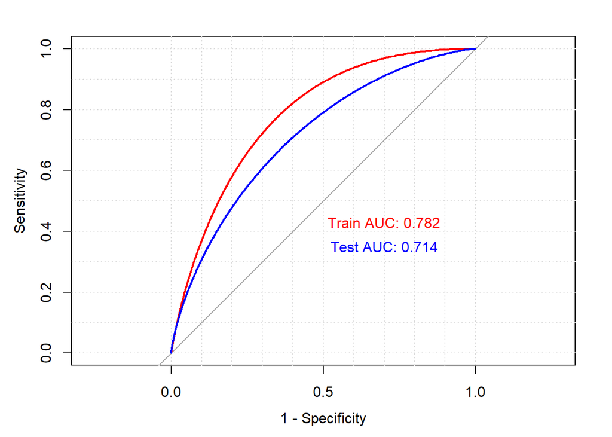

```r
# roc train on model
rocTrain=roc(caravanTrain,CARAVAN,probability,plot=TRUE,grid=TRUE,legacy.axes = TRUE,smooth=TRUE)
lines(rocTrain, col="red", type='l')
text(0.3, 0.43, labels=sprintf("Train AUC: %0.3f", auc(rocTrain)), col="red")

# roc test on model
rocTest=roc(caravanTest,CARAVAN,probability,plot=TRUE,add=TRUE,smooth=TRUE)
lines(rocTest, col="blue", type='l')
text(0.3, 0.35, labels=sprintf("Test AUC: %0.3f", auc(rocTest)), col="blue")
```

```r
# AUC of 0.782 and 0.714 for train and test respectively
```

Show lift curve

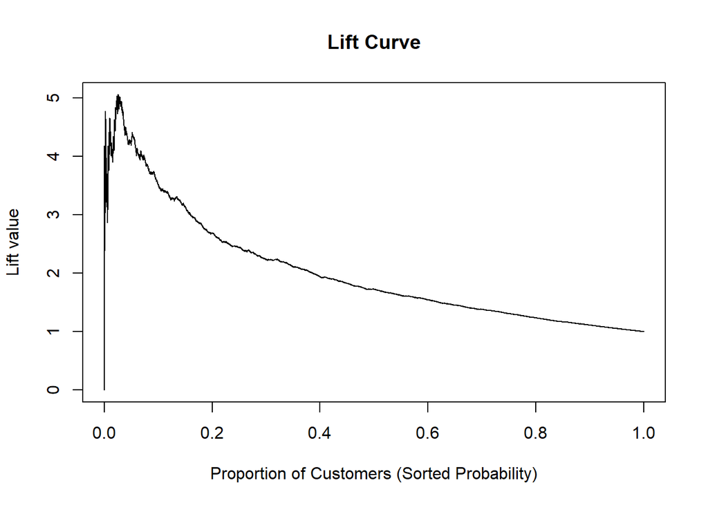

```r
# lift curve for train
pred = prediction(trainPredict, caravanTrain$CARAVAN)
perf = performance(pred, "lift", "rpp" )
plot(perf, main="Lift Curve", xlab = 'Proportion of Customers (Sorted Probability)')
```

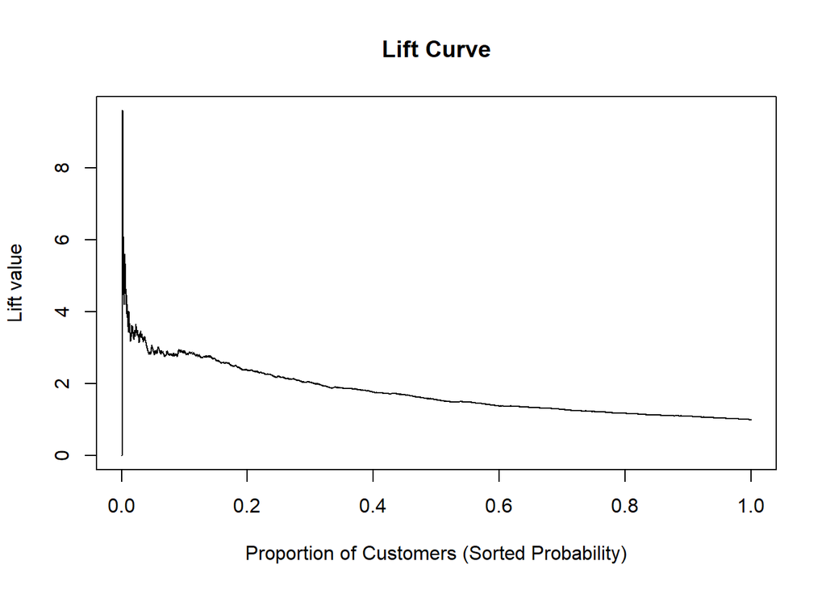

```r
# lift curve for test
pred = prediction(testPredict, caravanTest$CARAVAN)
perf = performance(pred, "lift", "rpp" )
plot(perf, main="Lift Curve", xlab = 'Proportion of Customers (Sorted Probability)')
```

Multiple probability by 1000 for scorecard generation use

```r
caravanTrain$score = trainPredict * 1000
caravanTest$score = testPredict * 1000

# rbind train and test set
overall = rbind(caravanTrain,caravanTest)
summary(overall)
```

```
##      Index         MOSTYPE        MAANTHUI         MGEMOMV
##  Min.   :   1   33     :1401   Min.   : 1.000   Min.   :1.000
##  1st Qu.:2456   38     : 569   1st Qu.: 1.000   1st Qu.:2.000
##  Median :4912   8      : 546   Median : 1.000   Median :3.000
##  Mean   :4912   39     : 542   Mean   : 1.109   Mean   :2.678
##  3rd Qu.:7367   9      : 460   3rd Qu.: 1.000   3rd Qu.:3.000
##  Max.   :9822   3      : 433   Max.   :10.000   Max.   :6.000
##                 (Other):5871
##     MOSHOOFD    CARAVAN    MGEMLEEF-0       MGODRK-0
##  8      :2694   0:9236   Min.   :24.50   Min.   :0.00000
##  3      :1513   1: 586   1st Qu.:34.50   1st Qu.:0.00000
##  9      :1111            Median :44.50   Median :0.00000
##  1      : 959            Mean   :44.47   Mean   :0.05486
##  5      : 940            3rd Qu.:44.50   3rd Qu.:0.05500
##  7      : 881            Max.   :75.00   Max.   :1.00000
##  (Other):1724
##     MGODPR-0         MGODOV-0          MGODGE-0         MRELGE-0
##  Min.   :0.0000   Min.   :0.00000   Min.   :0.0000   Min.   :0.0000
##  1st Qu.:0.4300   1st Qu.:0.00000   1st Qu.:0.1700   1st Qu.:0.5600
##  Median :0.5600   Median :0.05500   Median :0.3000   Median :0.6900
##  Mean   :0.5119   Mean   :0.08339   Mean   :0.3417   Mean   :0.7042
##  3rd Qu.:0.6900   3rd Qu.:0.17000   3rd Qu.:0.4300   3rd Qu.:0.8200
##  Max.   :1.0000   Max.   :0.56000   Max.   :1.0000   Max.   :1.0000
##
##     MRELSA-0          MRELOV-0        MFALLEEN-0       MFGEKIND-0
##  Min.   :0.00000   Min.   :0.0000   Min.   :0.0000   Min.   :0.000
##  1st Qu.:0.00000   1st Qu.:0.0550   1st Qu.:0.0000   1st Qu.:0.170
##  Median :0.05500   Median :0.1700   Median :0.1700   Median :0.300
##  Mean   :0.06705   Mean   :0.2264   Mean   :0.1842   Mean   :0.337
##  3rd Qu.:0.05500   3rd Qu.:0.3000   3rd Qu.:0.3000   3rd Qu.:0.430
##  Max.   :0.82000   Max.   :1.0000   Max.   :1.0000   Max.   :1.000
##
##    MFWEKIND-0       MOPLHOOG-0       MOPLMIDD-0       MOPLLAAG-0
##  Min.   :0.0000   Min.   :0.0000   Min.   :0.0000   Min.   :0.0000
##  1st Qu.:0.3000   1st Qu.:0.0000   1st Qu.:0.1700   1st Qu.:0.3000
##  Median :0.4300   Median :0.0550   Median :0.3000   Median :0.5600
##  Mean   :0.4696   Mean   :0.1393   Mean   :0.3468   Mean   :0.5073
##  3rd Qu.:0.6900   3rd Qu.:0.1700   3rd Qu.:0.4300   3rd Qu.:0.6900
##  Max.   :1.0000   Max.   :1.0000   Max.   :1.0000   Max.   :1.0000
##
```

[output cut: 81 more lines]

```
##  Min.   :-8.9461   Min.   :-17.47649   Min.   :-30.91522
##  1st Qu.:-0.8756   1st Qu.: -0.25755   1st Qu.: -0.26780
##  Median :-0.1776   Median : -0.04904   Median : -0.14755
##  Mean   : 0.0000   Mean   :  0.00000   Mean   :  0.00000
##  3rd Qu.: 0.5933   3rd Qu.:  0.18863   3rd Qu.:  0.07025
##  Max.   :22.5908   Max.   : 34.97165   Max.   : 30.05732
##
##   probability         score
##  Min.   :0.0000   Min.   :   0.0
##  1st Qu.:0.2100   1st Qu.: 210.0
##  Median :0.3708   Median : 370.8
##  Mean   :0.3941   Mean   : 394.1
##  3rd Qu.:0.5670   3rd Qu.: 567.0
##  Max.   :1.0000   Max.   :1000.0
##
```

```r
# original dataset is named "overall"
```

Show overall distribution of scores

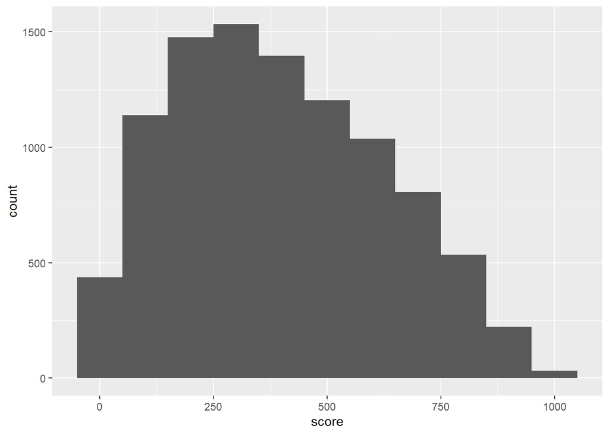

```r
overall %>%
  ggplot(aes(x = score)) +
    geom_histogram(binwidth=100)
```

Insert cluster information into “overall” dataset  
Read csv containing cluster information

```r
caravanTrainCluster <- read.csv("caravanTrain.csv")
caravanTestCluster  <- read.csv("caravanTest.csv")
```

Perform profiling by cluster number

```r
# perform profiling for train dataset
clustercountTrain = caravanTrainCluster %>%
  group_by(KMEDOID_4) %>%
  count(KMEDOID_4)

addmargins(table(caravanTrainCluster$KMEDOID_4, caravanTrainCluster$CARAVAN))
```

```
##
##          0    1  Sum
##   1   1793  170 1963
##   2   1209   79 1288
##   3   1299   46 1345
##   4    311    4  315
##   Sum 4612  299 4911
```

```r
# perform profiling for test dataset
clustercountTest = caravanTestCluster %>%
  group_by(KMEDOID_4) %>%
  count(KMEDOID_4)

addmargins(table(caravanTestCluster$KMEDOID_4, caravanTestCluster$CARAVAN))
```

```
##
##          0    1  Sum
##   1   1181   71 1252
##   2   1674  166 1840
##   3   1462   44 1506
##   4    307    6  313
##   Sum 4624  287 4911
```

```r
# show proportion of 0 and 1 for CARAVAN
caravanTrainCluster %>%
  group_by(KMEDOID_4, CARAVAN) %>%
  summarise(count = n(), percentage = n()/nrow(caravanTrainCluster))
```

```
## # A tibble: 8 x 4
## # Groups:   KMEDOID_4 [4]
##   KMEDOID_4 CARAVAN count percentage
##       <int>   <int> <int>      <dbl>
## 1         1       0  1793   0.365
## 2         1       1   170   0.0346
## 3         2       0  1209   0.246
## 4         2       1    79   0.0161
## 5         3       0  1299   0.265
## 6         3       1    46   0.00937
## 7         4       0   311   0.0633
## 8         4       1     4   0.000814
```

```r
str(caravanTestCluster$KMEDOID_4)
```

```
##  int [1:4911] 1 2 3 1 1 4 1 2 1 2 ...
```

```r
caravanTestCluster$KMEDOID_4 = factor(caravanTestCluster$KMEDOID_4)
```

Update cluster number by matching cluster distribution in train and test dataset

```r
# based on cluster distribution, cluster 1 in test corresponds to cluster 2 in train and
# cluster 2 in test corresponds to cluster 1 in train
# recode cluster no (KMEDOID_4) in caravanTest to be similar to cluster no in caravanTrain
# recode cluster 1 to 2 and recode cluster 2 to 1
caravanTestCluster = caravanTestCluster%>%
  mutate(KMEDOID_4new = recode_factor(KMEDOID_4, "2" = "5"))
caravanTestCluster = caravanTestCluster%>%
  mutate(KMEDOID_4new = recode_factor(KMEDOID_4new, "1" = "2"))
caravanTestCluster = caravanTestCluster%>%
  mutate(KMEDOID_4new = recode_factor(KMEDOID_4new, "5" = "1"))

caravanTestCluster$KMEDOID_4 = caravanTestCluster$KMEDOID_4new

caravanTestCluster = caravanTestCluster%>%
  select(-KMEDOID_4new)
```

Select only Index and kmedoid variables from cluster datasets

```r
caravanTrainCluster1 = caravanTrainCluster%>%
  select(c(Index, KMEDOID_4))

caravanTestCluster1 = caravanTestCluster%>%
  select(c(Index, KMEDOID_4))

CaravanOverallCluster = rbind(caravanTrainCluster1,caravanTestCluster1)
```

Append “overall” dataset to cluster dataset via join function

```r
overall2 = full_join(overall, CaravanOverallCluster, by = "Index")

# split dataset by cluster number
# based on conversion rate, we are only interested in binning cluster numbers 1 and 2
cluster1 = overall2 %>%
  filter(KMEDOID_4 == 1)

cluster2 = overall2 %>%
  filter(KMEDOID_4 == 2)
```

**Scorecard Generation**

Calculate goodrate for population

```r
overallGoodrate = sum(overall2$CARAVAN==1)/nrow(overall2)
```

Perform binning for cluster 1 and 2

```r
# binning for cluster 1
bins1 = rbin_manual(cluster1, CARAVAN, score, c(250, 340, 420, 510, 590, 680, 785)) #8 bins
binsCluster1 = data.frame(bins1[[1]])

# calculate lift for cluster1
# overallGoodrate = binsCluster1$good_cum_count[nrow(binsCluster1)]/ nrow(cluster1)
binsCluster1$lift = binsCluster1$good_rate/overallGoodrate;binsCluster1
```

```
##   cut_point bin bin_count good bad bin_cum_count good_cum_count
## 1     < 250   1       717   10 707           717             10
## 2     < 340   2       410   11 399          1127             21
## 3     < 420   3       424   18 406          1551             39
## 4     < 510   4       434   24 410          1985             63
## 5     < 590   5       446   44 402          2431            107
## 6     < 680   6       470   51 419          2901            158
## 7     < 785   7       472   78 394          3373            236
## 8    >= 785   8       430  100 330          3803            336
##   bad_cum_count  bin_prop  good_rate  bad_rate  good_dist   bad_dist
## 1           707 0.1885354 0.01394700 0.9860530 0.02976190 0.20392270
## 2          1106 0.1078096 0.02682927 0.9731707 0.03273810 0.11508509
## 3          1512 0.1114909 0.04245283 0.9575472 0.05357143 0.11710412
## 4          1922 0.1141204 0.05529954 0.9447005 0.07142857 0.11825786
## 5          2324 0.1172758 0.09865471 0.9013453 0.13095238 0.11595039
## 6          2743 0.1235866 0.10851064 0.8914894 0.15178571 0.12085376
## 7          3137 0.1241125 0.16525424 0.8347458 0.23214286 0.11364292
## 8          3467 0.1130686 0.23255814 0.7674419 0.29761905 0.09518316
##          woe   dist_diff          iv   entropy prop_entropy      lift
## 1  1.9245118  0.17416079 0.335174503 0.1059482   0.01997499 0.2337670
## 2  1.2571324  0.08234699 0.103521069 0.1782326   0.01921519 0.4496878
## 3  0.7820476  0.06353270 0.049685593 0.2534275   0.02825486 0.7115558
## 4  0.5041695  0.04682929 0.023609901 0.3084961   0.03520570 0.9268807
## 5 -0.1216713 -0.01500199 0.001825312 0.4647166   0.05450002 1.6535607
## 6 -0.2278885 -0.03093195 0.007049036 0.4954072   0.06122571 1.8187568
## 7 -0.7142917 -0.11849994 0.084643523 0.6467325   0.08026761 2.7698415
## 8 -1.1400113 -0.20243589 0.230779208 0.7824441   0.08846989 3.8979284
```

```r
# binning for cluster2
bins2 = rbin_manual(cluster2, CARAVAN, score, c(340, 410, 480, 540, 610, 700)) #7 bins
binsCluster2 = data.frame(bins2[[1]])

# calculate lift for cluster2
binsCluster2$lift = binsCluster2$good_rate/overallGoodrate;binsCluster2
```

```
##   cut_point bin bin_count good bad bin_cum_count good_cum_count
## 1     < 340   1       628    7 621           628              7
## 2     < 410   2       311   12 299           939             19
## 3     < 480   3       335   15 320          1274             34
## 4     < 540   4       314   21 293          1588             55
## 5     < 610   5       315   22 293          1903             77
## 6     < 700   6       313   23 290          2216            100
## 7    >= 700   7       324   50 274          2540            150
##   bad_cum_count  bin_prop  good_rate  bad_rate  good_dist  bad_dist
## 1           621 0.2472441 0.01114650 0.9888535 0.04666667 0.2598326
## 2           920 0.1224409 0.03858521 0.9614148 0.08000000 0.1251046
## 3          1240 0.1318898 0.04477612 0.9552239 0.10000000 0.1338912
## 4          1533 0.1236220 0.06687898 0.9331210 0.14000000 0.1225941
## 5          1826 0.1240157 0.06984127 0.9301587 0.14666667 0.1225941
## 6          2116 0.1232283 0.07348243 0.9265176 0.15333333 0.1213389
## 7          2390 0.1275591 0.15432099 0.8456790 0.33333333 0.1146444
##          woe   dist_diff          iv    entropy prop_entropy      lift
## 1  1.7170076  0.21316597 0.366007586 0.08830133   0.02183198 0.1868275
## 2  0.4471236  0.04510460 0.020167331 0.23576739   0.02886758 0.6467302
## 3  0.2918574  0.03389121 0.009891403 0.26377744   0.03478954 0.7504967
## 4 -0.1327632 -0.01740586 0.002310857 0.35416717   0.04378287 1.1209648
## 5 -0.1792832 -0.02407252 0.004315799 0.36533102   0.04530680 1.1706160
## 6 -0.2340266 -0.03199442 0.007487547 0.37878702   0.04667730 1.2316457
## 7 -1.0673082 -0.21868898 0.233408555 0.62054877   0.07915661 2.5865883
```

Generate scorecard

```r
scorecard1 = data.frame(binsCluster1['bin'],binsCluster1['cut_point'],binsCluster1['bin_count'],binsCluster1['good'],binsCluster1['bin_cum_count'],round(binsCluster1['bin_prop']*100,1), round(binsCluster1['good_rate']*100,2), round(binsCluster1['lift'],2))
scorecard2 = data.frame(binsCluster2['bin'],binsCluster2['cut_point'],binsCluster2['bin_count'],binsCluster2['good'],binsCluster2['bin_cum_count'],round(binsCluster2['bin_prop']*100,1), round(binsCluster2['good_rate']*100,2), round(binsCluster2['lift'],2))

# reorder bin number
scorecard1 = arrange(scorecard1, desc(bin))
scorecard1 = select(scorecard1, -bin)
scorecard1$bin = seq(1,8)
scorecard1
```

```
##   cut_point bin_count good bin_cum_count bin_prop good_rate lift bin
## 1    >= 785       430  100          3803     11.3     23.26 3.90   1
## 2     < 785       472   78          3373     12.4     16.53 2.77   2
## 3     < 680       470   51          2901     12.4     10.85 1.82   3
## 4     < 590       446   44          2431     11.7      9.87 1.65   4
## 5     < 510       434   24          1985     11.4      5.53 0.93   5
## 6     < 420       424   18          1551     11.1      4.25 0.71   6
## 7     < 340       410   11          1127     10.8      2.68 0.45   7
## 8     < 250       717   10           717     18.9      1.39 0.23   8
```

```r
scorecard2 = arrange(scorecard2, desc(bin))
scorecard2 = select(scorecard2, -bin)
scorecard2$bin = seq(1,7)
scorecard2
```

```
##   cut_point bin_count good bin_cum_count bin_prop good_rate lift bin
## 1    >= 700       324   50          2540     12.8     15.43 2.59   1
## 2     < 700       313   23          2216     12.3      7.35 1.23   2
## 3     < 610       315   22          1903     12.4      6.98 1.17   3
## 4     < 540       314   21          1588     12.4      6.69 1.12   4
## 5     < 480       335   15          1274     13.2      4.48 0.75   5
## 6     < 410       311   12           939     12.2      3.86 0.65   6
## 7     < 340       628    7           628     24.7      1.11 0.19   7
```

```r
# rename variable
scorecard1=rename(scorecard1,"good_rate(%)"=good_rate)
scorecard2=rename(scorecard2,"good_rate(%)"=good_rate)
```

Plot lift curve for clusters 1 and 2 with updated bin number

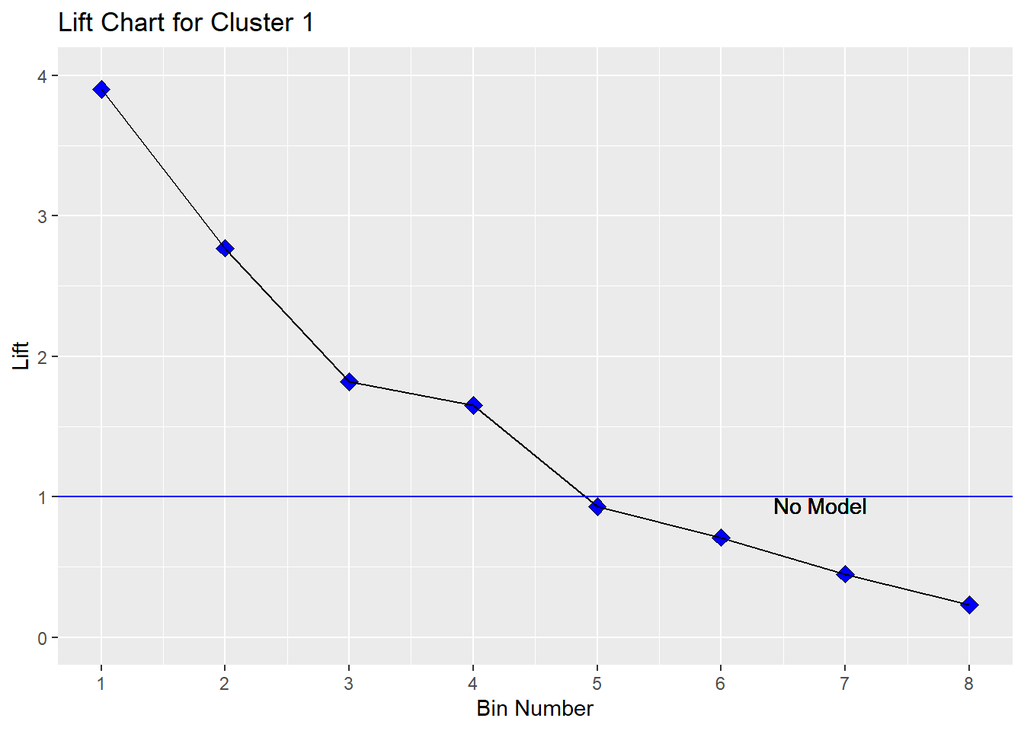

```r
# re-plot lift for cluster 1 with updated bin number
scorecard1 %>%
  ggplot(aes(x = bin, y = lift)) +
  geom_point(shape=23, fill="blue", size=3) + geom_line() + geom_hline(yintercept = 1, col = "blue") +
  ggtitle("Lift Chart for Cluster 1") + ylab("Lift") + scale_x_continuous(breaks = seq(1,8, by = 1)) +
  xlab("Bin Number") + geom_text(aes(0,1,label = "No Model", vjust = 1, hjust = -8.5)) +
  coord_cartesian(xlim = c(1, 8), ylim = c(0, 4))
```

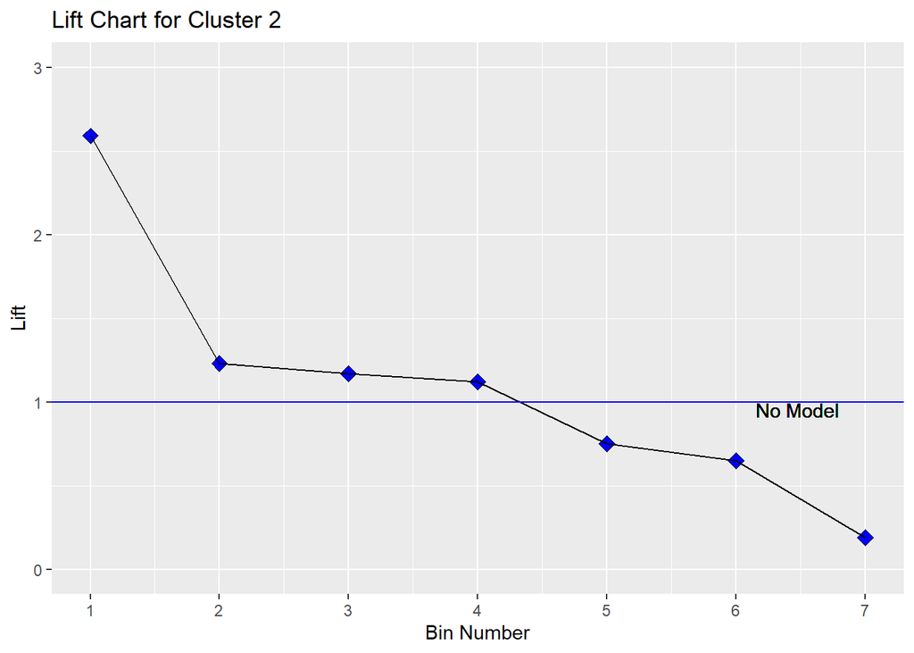

```r
# re-plot lift for cluster 2 with updated bin number
scorecard2 %>%
  ggplot(aes(x = bin, y = lift)) +
  geom_point(shape=23, fill="blue", size=3) + geom_line() + geom_hline(yintercept = 1, col = "blue") +
  ggtitle("Lift Chart for Cluster 2") + ylab("Lift") + scale_x_continuous(breaks = seq(1,7, by = 1)) +
  xlab("Bin Number") + geom_text(aes(0,1,label = "No Model", vjust = 1, hjust = -9.5)) +
  coord_cartesian(xlim = c(1, 7), ylim = c(0, 3))
```

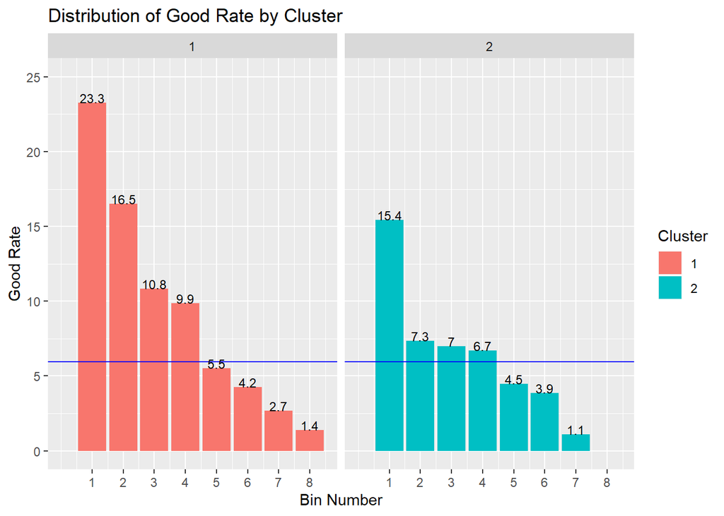

```r
# compare goodrate of cluster 1 and 2
Compare = rbind(scorecard1, scorecard2)
Compare$cluster = rep(c(1, 2), times = c(8, 7))

Compare %>%
  ggplot(aes(x = bin, y = `good_rate(%)`, fill = as.factor(cluster))) +
  geom_bar(stat='identity') + facet_wrap(~cluster) + geom_hline(yintercept = overallGoodrate*100, col = "blue") +
  labs(x= "Bin Number", y= "Good Rate", fill = "cluster",
     title = "Distribution of Good Rate by Cluster") + coord_cartesian(ylim = c(0, 25)) +
  scale_fill_discrete(name = "Cluster") + scale_x_continuous(breaks = seq(1,8, by = 1)) +
  geom_text(aes(label=round(`good_rate(%)`,1)),vjust = 0, size = 3.2) +
  geom_text(aes(0,1,label = "5.97", vjust = -5.5, hjust = -12), size = 3)
```